# ‘SongEvo’ package

Raymond M. Danner, Elizabeth P. Derryberry, Graham E. Derryberry, Julie E. Danner, Sara J. Evans, David A. Luther

2020-01-29

## Introduction

SongEvo simulates the cultural evolution of quantitative traits of bird song. SongEvo is an individual- (agent-) based model. SongEvo is spatially-explicit and can be parameterized with, and tested against, measured song data. Functions are available for model implementation, sensitivity analyses, parameter optimization, model validation, and hypothesis testing.

### Overview of Functions

1. `SongEvo` implements the model
2. `par.sens` allows sensitivity analyses
3. `par.opt` allows parameter optimization
4. `mod.val` allows model validation
5. `h.test` allows hypothesis testing

## Getting Started

### Load and attach SongEvo package

```r
library(SongEvo)
```

### Functions

`SongEvo` implements the model `par.sens` allows sensitivity analyses `par.opt` allows parameter optimization `mod.val` allows model validation `h.test` allows hypothesis testing

## Examples

### EXAMPLE 1

### Load the example data: song.data and global parameters

To explore the SongEvo package, we will use a database of songs from Nuttall’s white-crowned sparrow (*Zonotrichia leucophrys nuttalli*) recorded at three locations in 1969 and 2005.

```r
data("song.data")
```

Examine global parameters. Global parameters describe our understanding of the system and may be measured or hypothesized. They are called “global” because they are used by many many functions and subroutines within functions. For descriptions of all adjustable parameters, see `?song.data`.

```r
data("glo.parms")
glo.parms$mortality.a.m <- glo.parms$mortality.a.f <- glo.parms$mortality.a
glo.parms$mortality.j.m <- glo.parms$mortality.j.f <- glo.parms$mortality.j
glo.parms$male.fledge.n.mean <- glo.parms$male.fledge.n.mean*2
glo.parms$male.fledge.n.sd <- glo.parms$male.fledge.n.sd*2
glo.parms <- glo.parms[!names(glo.parms) %in% c("mortality.a","mortality.j")]
str(glo.parms)
```

```
#> List of 17
#>  $ learning.error.d  : num 0
#>  $ learning.error.sd : num 430
#>  $ n.territories     : num 40
#>  $ lifespan          : num 2.08
#>  $ phys.lim.min      : num 1559
#>  $ phys.lim.max      : num 4364
#>  $ male.fledge.n.mean: num 2.7
#>  $ male.fledge.n.sd  : num 1
#>  $ disp.age          : num 2
#>  $ disp.distance.mean: num 110
#>  $ disp.distance.sd  : num 100
#>  $ terr.turnover     : num 0.5
#>  $ male.fledge.n     : num [1:40] 1 1 2 1 0 2 2 2 2 1 ...
#>  $ mortality.a.f     : num 0.468
#>  $ mortality.a.m     : num 0.468
#>  $ mortality.j.f     : num 0.5
#>  $ mortality.j.m     : num 0.5
```

Share global parameters with the global environment. We make these parameters available in the global environment so that we can access them with minimal code.

```r
list2env(glo.parms, globalenv())
```

```
#> <environment: R_GlobalEnv>
```

#### Examine song data

Data include the population name (Bear Valley, PRBO, or Schooner), year of song recording (1969 or 2005), and the frequency bandwidth of the trill.

```r
str(song.data)
```

```
#> 'data.frame':    89 obs. of  3 variables:
#>  $ Population: Factor w/ 3 levels "Bear Valley",..: 3 3 3 3 3 3 3 3 3 3 ...
#>  $ Year      : int  1969 1969 1969 1969 1969 1969 1969 1969 1969 1969 ...
#>  $ Trill.FBW : num  3261 2494 2806 2878 2758 ...
```

### Simulate bird song evolution with `SongEvo()`

#### Define initial individuals

In this example, we use songs from individual birds recorded in one population (PRBO) in the year 1969, which we will call `starting.trait`.

```r
starting.trait <- subset(song.data, Population=="PRBO" & Year==1969)$Trill.FBW
```

We want a starting population of 40 individuals, so we generate additional trait values to complement those from the existing 30 individuals. Then we create a data frame that includes a row for each individual; we add identification numbers, ages, and geographical coordinates for each individual.

```r
starting.trait2 <- c(starting.trait, rnorm(n.territories-length(starting.trait),
    mean=mean(starting.trait), sd=sd(starting.trait)))
init.inds <- data.frame(id = seq(1:n.territories), age = 2, trait = starting.trait2)
init.inds$x1 <-  round(runif(n.territories, min=-122.481858, max=-122.447270), digits=8)
init.inds$y1 <-  round(runif(n.territories, min=37.787768, max=37.805645), digits=8)
```

#### Specify and call the SongEvo model

`SongEvo()` includes several settings, which we specify before running the model. For this example, we run the model for 10 iterations, over 36 years (i.e. 1969–2005). When conducting research with `SongEvo()`, users will want to increase the number iterations (e.g. to 100 or 1000). Each timestep is one year in this model (i.e. individuals complete all components of the model in 1 year). We specify territory turnover rate here as an example of how to adjust parameter values. We could adjust any other parameter value here also. The learning method specifies that individuals integrate songs heard from adults within the specified integration distance (intigrate.dist, in kilometers). In this example, we do not includ a lifespan, so we assign it NA. In this example, we do not model competition for mates, so specify it as FALSE. Last, specify all as TRUE in order to save data for every single simulated individual because we will use those data later for mapping. If we do not need data for each individual, we set all to FALSE because the all.inds data.frame becomes very large!

```r
iteration <- 10
years <- 36
timestep <- 1
terr.turnover <- 0.5
integrate.dist <- 0.1
lifespan <- NA
mate.comp <- FALSE
prin <- FALSE
all <- TRUE
```

Now we call SongEvo with our specifications and save it in an object called SongEvo1.

```r
SongEvo1 <- SongEvo(init.inds = init.inds, females = 1.0, iteration = iteration, steps = years,
    timestep = timestep, n.territories = n.territories, terr.turnover = terr.turnover,
    integrate.dist = integrate.dist,
    learning.error.d = learning.error.d, learning.error.sd = learning.error.sd,
    mortality.a.m = mortality.a.m, mortality.a.f = mortality.a.f,
    mortality.j.m = mortality.j.m, mortality.j.f = mortality.j.f, lifespan = lifespan,
    phys.lim.min = phys.lim.min, phys.lim.max = phys.lim.max,
    male.fledge.n.mean = male.fledge.n.mean, male.fledge.n.sd = male.fledge.n.sd, male.fledge.n = male.fledge.n,
    disp.age = disp.age, disp.distance.mean = disp.distance.mean, disp.distance.sd = disp.distance.sd,
    mate.comp = mate.comp, prin = prin, all = TRUE)
```

#### Examine results from SongEvo model

The model required the following time to run on your computer:

```r
SongEvo1$time
```

```
#>    user  system elapsed
#>  34.087   0.511  35.440
```

Three main objects hold data regarding the SongEvo model. Additional objects are used temporarily within modules of the model.

First, currently alive individuals are stored in a data frame called “inds.” Values within “inds” are updated throughout each of the iterations of the model, and “inds” can be viewed after the model is completed.

```r
head(SongEvo1$inds, min(5,nrow(SongEvo1$inds)))
```

```
#>                 coordinates   id age    trait        x1       y1
#> M1559 (-122.4774, 37.79637) 1559   8 3267.083 -122.4774 37.79637
#> M1627  (-122.4455, 37.8023) 1627   7 4364.000 -122.4455 37.80230
#> M1651 (-122.4786, 37.79366) 1651   6 3985.899 -122.4786 37.79366
#> M1701 (-122.4764, 37.79216) 1701   5 4364.000 -122.4764 37.79216
#> M1706  (-122.481, 37.78642) 1706   5 3373.668 -122.4810 37.78642
#>       male.fledglings female.fledglings territory father sex fitness learn.dir
#> M1559               0                 0         0   1471   M       1         0
#> M1627               0                 0         0   1549   M       1         0
#> M1651               1                 1         1   1261   M       1         0
#> M1701               2                 0         1   1525   M       1         0
#> M1706               3                 1         1   1578   M       1         0
#>              x0       y0
#> M1559 -122.4754 37.79578
#> M1627 -122.4453 37.80235
#> M1651 -122.4789 37.79247
#> M1701 -122.4760 37.79167
#> M1706 -122.4804 37.78737
```

```r
dimnames(SongEvo1$summary.results)
```

```
#> $iteration
#>  [1] "iteration 1"  "iteration 2"  "iteration 3"  "iteration 4"  "iteration 5"
#>  [6] "iteration 6"  "iteration 7"  "iteration 8"  "iteration 9"  "iteration 10"
#>
#> $step
#>  [1] "1"  "2"  "3"  "4"  "5"  "6"  "7"  "8"  "9"  "10" "11" "12" "13" "14" "15"
#> [16] "16" "17" "18" "19" "20" "21" "22" "23" "24" "25" "26" "27" "28" "29" "30"
#> [31] "31" "32" "33" "34" "35" "36"
#>
#> $feature
#> [1] "sample.n"           "trait.pop.mean"     "trait.pop.variance"
#> [4] "lci"                "uci"
```

Third, individual values may optionally be concatenated and saved to one data frame entitled “all.inds.” all.inds can become quite large, and is therefore only recommended if additional data analyses are desired.

```r
head(SongEvo1$all.inds,  min(5,nrow(SongEvo1$all.inds)))
```

```
#>                   coordinates id age  trait        x1       y1 male.fledglings
#> I1.T1.1  (-122.4686, 37.7968)  1   2 4004.8 -122.4686 37.79680               1
#> I1.T1.2 (-122.4645, 37.80218)  2   2 3765.0 -122.4645 37.80218               0
#> I1.T1.3 (-122.4672, 37.80161)  3   2 3237.4 -122.4672 37.80161               2
#> I1.T1.4 (-122.4615, 37.78782)  4   2 3621.1 -122.4615 37.78782               0
#> I1.T1.5 (-122.4537, 37.79911)  5   2 3285.4 -122.4537 37.79911               0
#>         female.fledglings territory father sex fitness learn.dir x0 y0 timestep
#> I1.T1.1                 0         1      0   M       1         0  0  0        1
#> I1.T1.2                 1         1      0   M       1         0  0  0        1
#> I1.T1.3                 0         1      0   M       1         0  0  0        1
#> I1.T1.4                 1         1      0   M       1         0  0  0        1
#> I1.T1.5                 0         1      0   M       1         0  0  0        1
#>         iteration
#> I1.T1.1         1
#> I1.T1.2         1
#> I1.T1.3         1
#> I1.T1.4         1
#> I1.T1.5         1
```

#### Simulated population size

We see that the simulated population size remains relatively stable over the course of 36 years. This code uses the summary.results array.

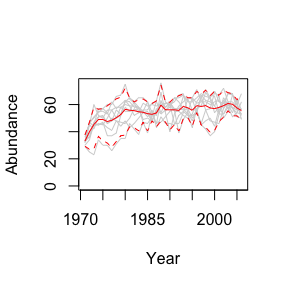

```r
plot(SongEvo1$summary.results[1, , "sample.n"], xlab="Year", ylab="Abundance", type="n",
    xaxt="n", ylim=c(0, max(SongEvo1$summary.results[, , "sample.n"], na.rm=TRUE)))
axis(side=1, at=seq(0, 40, by=5), labels=seq(1970, 2010, by=5))
    for(p in 1:iteration){
        lines(SongEvo1$summary.results[p, , "sample.n"], col="light gray")
        }
n.mean <- apply(SongEvo1$summary.results[, , "sample.n"], 2, mean, na.rm=TRUE)
lines(n.mean, col="red")

#Plot 95% quantiles
quant.means <- apply (SongEvo1$summary.results[, , "sample.n"], MARGIN=2, quantile,
    probs=c(0.975, 0.025), R=600, na.rm=TRUE)
lines(quant.means[1,], col="red", lty=2)
lines(quant.means[2,], col="red", lty=2)
```

Load Hmisc package for plotting functions.

```r
library("Hmisc")
```

#### Simulated trait values

We see that the mean trait values per iteration varied widely, though mean trait values over all iterations remained relatively stable. This code uses the summary.results array.

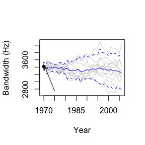

```r
plot(SongEvo1$summary.results[1, , "trait.pop.mean"], xlab="Year", ylab="Bandwidth (Hz)",
    xaxt="n", type="n", xlim=c(-0.5, 36),
    ylim=c(min(SongEvo1$summary.results[, , "trait.pop.mean"], na.rm=TRUE),
    max(SongEvo1$summary.results[, , "trait.pop.mean"], na.rm=TRUE)))
    for(p in 1:iteration){
        lines(SongEvo1$summary.results[p, , "trait.pop.mean"], col="light gray")
        }
freq.mean <- apply(SongEvo1$summary.results[, , "trait.pop.mean"], 2, mean, na.rm=TRUE)
lines(freq.mean, col="blue")
axis(side=1, at=seq(0, 35, by=5), labels=seq(1970, 2005, by=5))#, tcl=-0.25, mgp=c(2,0.5,0))

#Plot 95% quantiles
quant.means <- apply (SongEvo1$summary.results[, , "trait.pop.mean"], MARGIN=2, quantile,
    probs=c(0.95, 0.05), R=600, na.rm=TRUE)
lines(quant.means[1,], col="blue", lty=2)
lines(quant.means[2,], col="blue", lty=2)

#plot mean and CI for historic songs.
 #plot original song values
library("boot")
sample.mean <- function(d, x) {
    mean(d[x])
}
boot_hist <- boot(starting.trait, statistic=sample.mean, R=100)#, strata=mn.res$iteration)
ci.hist <- boot.ci(boot_hist, conf=0.95, type="basic")
low <- ci.hist$basic[4]
high <- ci.hist$basic[5]
points(0, mean(starting.trait), pch=20, cex=0.6, col="black")
errbar(x=0, y=mean(starting.trait), high, low, add=TRUE)
 #text and arrows
text(x=5, y=2720, labels="Historical songs", pos=1)
arrows(x0=5, y0=2750, x1=0.4, y1=mean(starting.trait), length=0.1)
```

#### Trait variance

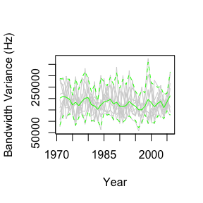

```r
 #plot variance for each iteration per year
plot(SongEvo1$summary.results[1, , "trait.pop.variance"], xlab="Year",
    ylab="Bandwidth Variance (Hz)", type="n", xaxt="n",
    ylim=c(min(SongEvo1$summary.results[, , "trait.pop.variance"], na.rm=TRUE),
    max(SongEvo1$summary.results[, , "trait.pop.variance"], na.rm=TRUE)))
axis(side=1, at=seq(0, 40, by=5), labels=seq(1970, 2010, by=5))
    for(p in 1:iteration){
        lines(SongEvo1$summary.results[p, , "trait.pop.variance"], col="light gray")
        }
n.mean <- apply(SongEvo1$summary.results[, , "trait.pop.variance"], 2, mean, na.rm=TRUE)
lines(n.mean, col="green")

#Plot 95% quantiles
quant.means <- apply (SongEvo1$summary.results[, , "trait.pop.variance"], MARGIN=2, quantile,
    probs=c(0.975, 0.025), R=600, na.rm=TRUE)
lines(quant.means[1,], col="green", lty=2)
lines(quant.means[2,], col="green", lty=2)
```

#### Maps

The simulation results include geographical coordinates and are in a standard spatial data format, thus allowing calculation of a wide variety of spatial statistics.

Load packages for making maps.

```r
library("sp")
library("reshape2")
library("lattice")
```

Convert data frame from long to wide format. This is necessary for making a multi-panel plot.

```r
all.inds1 <- subset(SongEvo1$all.inds, SongEvo1$all.inds$iteration==1)
w <- dcast(as.data.frame(all.inds1), id ~ timestep, value.var="trait", fill=0)
all.inds1w <- merge(all.inds1, w, by="id")
years.SongEvo1 <- (dim(w)[2]-1 )
names(all.inds1w@data)[-(1:length(all.inds1@data))] <-paste("Ts", 1:(dim(w)[2]-1 ), sep="")
```

Create a function to generate a continuous color palette–we will use the palette in the next call to make color ramp to represent the trait value.

```r
rbPal <- colorRampPalette(c('blue','red')) #Create a function to generate a continuous color palette
```

Plot maps, including a separate panel for each timestep (each of 36 years). Our example shows that individuals move across the landscape and that regional dialects evolve and move. The x-axis is longitude, the y-axis is latitude, and the color ramp indicates trill bandwidth in Hz.

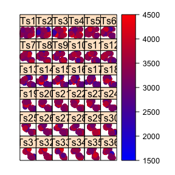

```r
spplot(all.inds1w[,-c(1:ncol(all.inds1))], as.table=TRUE,
    cuts=c(0, seq(from=1500, to=4500, by=10)), ylab="",
    col.regions=c("transparent", rbPal(1000)),
    #cuts specifies that the first level (e.g. <1500) is transparent.
colorkey=list(
    right=list(
          fun=draw.colorkey,
          args=list(
                key=list(
                at=seq(1500, 4500, 10),
                col=rbPal(1000),
                labels=list(
                at=c(1500, 2000, 2500, 3000, 3500, 4000, 4500),
                labels=c("1500", "2000", "2500", "3000", "3500", "4000", "4500")
                )
                )
                )
            )
    )
)
```

In addition, you can plot simpler multi-panel maps that do not take advantage of the spatial data class.

[figure not shown]

```r
 #Lattice plot (not as a spatial frame)
it1 <- subset(SongEvo1$all.inds, iteration==1)
rbPal <- colorRampPalette(c('blue','red')) #Create a function to generate a continuous color palette
it1$Col <- rbPal(10)[as.numeric(cut(it1$trait, breaks = 10))]
xyplot(it1$y1~it1$x1 | it1$timestep, groups=it1$trait, asp="iso", col=it1$Col,
    xlab="Longitude", ylab="Latitude")
```

### Test model sensitivity with `par.sens()`

This function allows testing the sensitivity of SongEvo to different parameter values.

#### Specify and call `par.sens()`

Here we test the sensitivity of the Acquire a Territory submodel to variation in territory turnover rates, ranging from 0.8–1.2 times the published rate (40–60% of territories turned over). The call for the par.sens function has a format similar to SongEvo. The user specifies the parameter to test and the range of values for that parameter. The function currently allows examination of only one parameter at a time and requires at least two iterations.

```r
parm <- "terr.turnover"
par.range = seq(from=0.4, to=0.6, by=0.025)
sens.results <- NULL
```

Now we call the par.sens function with our specifications.

```r
extra_parms <- list(init.inds = init.inds,
                    females = 1,  # New in SongEvo v2
                    timestep = 1,
                    n.territories = nrow(init.inds),
                    integrate.dist = 0.1,
                    lifespan = NA,
                    terr.turnover = 0.5,
                    mate.comp = FALSE,
                    prin = FALSE,
                    all = TRUE,
                    # New in SongEvo v2
                    selectivity = 3,
                    content.bias = FALSE,
                    n.content.bias.loc = "all",
                    content.bias.loc = FALSE,
                    content.bias.loc.ranges = FALSE,
                    affected.traits = FALSE,
                    conformity.bias = FALSE,
                    prestige.bias=FALSE,
                    learn.m="default",
                    learn.f="default",
                    learning.error.d=0,
                    learning.error.sd=200)
global_parms_key <- which(!names(glo.parms) %in% names(extra_parms))
extra_parms[names(glo.parms[global_parms_key])]=glo.parms[global_parms_key]
par.sens1 <- par.sens(parm = parm, par.range = par.range,
                      iteration = iteration, steps = years, mate.comp = FALSE,
                      fixed_parms=extra_parms[names(extra_parms)!=parm], all = TRUE)
```

```
#> [1] "terr.turnover =  0.4"
#> [1] "terr.turnover =  0.425"
#> [1] "terr.turnover =  0.45"
#> [1] "terr.turnover =  0.475"
#> [1] "terr.turnover =  0.5"
#> [1] "terr.turnover =  0.525"
#> [1] "terr.turnover =  0.55"
#> [1] "terr.turnover =  0.575"
#> [1] "terr.turnover =  0.6"
```

#### Examine par.sens results

Examine results objects, which include two arrays:

The first array, `sens.results`, contains the SongEvo model results for each parameter. It has the following dimensions:

```r
dimnames(par.sens1$sens.results)
```

```
#> [[1]]
#>  [1] "iteration 1"  "iteration 2"  "iteration 3"  "iteration 4"  "iteration 5"
#>  [6] "iteration 6"  "iteration 7"  "iteration 8"  "iteration 9"  "iteration 10"
#>
#> [[2]]
#>  [1] "1"  "2"  "3"  "4"  "5"  "6"  "7"  "8"  "9"  "10" "11" "12" "13" "14" "15"
#> [16] "16" "17" "18" "19" "20" "21" "22" "23" "24" "25" "26" "27" "28" "29" "30"
#> [31] "31" "32" "33" "34" "35" "36"
#>
#> [[3]]
#> [1] "sample.n"           "trait.pop.mean"     "trait.pop.variance"
#> [4] "lci"                "uci"
#>
#> [[4]]
#> [1] "par.val 0.4"   "par.val 0.425" "par.val 0.45"  "par.val 0.475"
#> [5] "par.val 0.5"   "par.val 0.525" "par.val 0.55"  "par.val 0.575"
#> [9] "par.val 0.6"
```

The second array, `sens.results.diff` contains the quantile range of trait values across iterations within a parameter value. It has the following dimensions:

```r
dimnames(par.sens1$sens.results.diff)
```

```
#> [[1]]
#> [1] "par.val 0.4"   "par.val 0.425" "par.val 0.45"  "par.val 0.475"
#> [5] "par.val 0.5"   "par.val 0.525" "par.val 0.55"  "par.val 0.575"
#> [9] "par.val 0.6"
#>
#> [[2]]
#>  [1] "Quantile diff 1"  "Quantile diff 2"  "Quantile diff 3"  "Quantile diff 4"
#>  [5] "Quantile diff 5"  "Quantile diff 6"  "Quantile diff 7"  "Quantile diff 8"
#>  [9] "Quantile diff 9"  "Quantile diff 10" "Quantile diff 11" "Quantile diff 12"
#> [13] "Quantile diff 13" "Quantile diff 14" "Quantile diff 15" "Quantile diff 16"
#> [17] "Quantile diff 17" "Quantile diff 18" "Quantile diff 19" "Quantile diff 20"
#> [21] "Quantile diff 21" "Quantile diff 22" "Quantile diff 23" "Quantile diff 24"
#> [25] "Quantile diff 25" "Quantile diff 26" "Quantile diff 27" "Quantile diff 28"
#> [29] "Quantile diff 29" "Quantile diff 30" "Quantile diff 31" "Quantile diff 32"
#> [33] "Quantile diff 33" "Quantile diff 34" "Quantile diff 35" "Quantile diff 36"
```

To assess sensitivity of SongEvo to a range of parameter values, plot the range in trait quantiles per year by the parameter value. We see that territory turnover values of 0.4–0.6 provided means and quantile ranges of trill bandwidths that are similar to those obtained with the published estimate of 0.5, indicating that the Acquire a Territory submodel is robust to realistic variation in those parameter values.

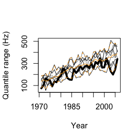

```r
 #plot of range in trait quantiles by year by parameter value
plot(1:years, par.sens1$sens.results.diff[1,], ylim=c(min(par.sens1$sens.results.diff,
    na.rm=TRUE), max(par.sens1$sens.results.diff, na.rm=TRUE)), type="l",
    ylab="Quantile range (Hz)", xlab="Year", col="transparent", xaxt="n")
axis(side=1, at=seq(0, 35, by=5), labels=seq(1970, 2005, by=5))

  #Make a continuous color ramp from gray to black
grbkPal <- colorRampPalette(c('gray','black'))

  #Plot a line for each parameter value
for(i in 1:length(par.range)){
lines(1:years, par.sens1$sens.results.diff[i,], type="l",
    col=grbkPal(length(par.range))[i])
}

  #Plot values from published parameter values
lines(1:years, par.sens1$sens.results.diff[2,], type="l", col="black", lwd=4)

  #Calculate and plot mean and quantiles
quant.mean <- apply(par.sens1$sens.results.diff, 2, mean, na.rm=TRUE)
lines(quant.mean, col="orange")

#Plot 95% quantiles (which are similar to credible intervals)
  #95% quantiles of population means (narrower)
quant.means <- apply (par.sens1$sens.results.diff, MARGIN=2, quantile,
    probs=c(0.975, 0.025), R=600, na.rm=TRUE)
lines(quant.means[1,], col="orange", lty=2)
lines(quant.means[2,], col="orange", lty=2)
```

### Optimize parameter values with `par.opt()`

This function follows par.sens to help users optimize values for imperfectly known parameters for SongEvo. The goals are to maximize accuracy and precision of model prediction. Accuracy is quantified by three different approaches: i) the mean of absolute residuals of the predicted population mean values in relation to target data (e.g. observed or hypothetical values (smaller absolute residuals indicate a more accurate model)), ii) the difference between the bootstrapped mean of predicted population means and the mean of the target data, and iii) the proportion of simulated population trait means that fall within (i.e. are “contained by”) the confidence intervals of the target data (a higher proportion indicates greater accuracy). Precision is measured with the residuals of the predicted population variance to the variance of target data (smaller residuals indicate a more precise model).

#### Prepare current song values

```r
target.data <- subset(song.data, Population=="PRBO" & Year==2005)$Trill.FBW
```

#### Specify and call `par.opt()`

Users specify the timestep (“ts”) at which to compare simulated trait values to target trait data (“target.data”) and save the results in an object (called `par.opt1` here).

```r
ts <- years
par.opt1 <- par.opt(sens.results=par.sens1$sens.results, ts=ts,
    target.data=target.data, par.range=par.range)
```

Examine results objects (residuals and target match).

```r
par.opt1$Residuals
```

```
#> , , Residuals of mean
#>
#>               Iteration 1 Iteration 2 Iteration 3 Iteration 4 Iteration 5
#> par.val 0.4     553.74569   248.59428    61.52022 325.5223031   291.07846
#> par.val 0.425   218.85181    96.53497   135.08190 131.8876836   280.31459
#> par.val 0.45     51.94299   381.94572   517.39748 195.1616407   116.74329
#> par.val 0.475    46.27553   311.44916   287.84070 331.8257937     6.18017
#> par.val 0.5     118.74635    23.96550   371.65580  81.5568169    16.87986
#> par.val 0.525   180.38735   263.99070   116.69448  56.0882155   121.36963
#> par.val 0.55    243.17372   381.34396   251.58065  40.4965957   325.78838
#> par.val 0.575   172.80867   120.16039   134.24328 452.6087555   363.57685
#> par.val 0.6     359.18821   176.76328    21.14528   0.5942235   455.24061
#>               Iteration 6 Iteration 7 Iteration 8 Iteration 9 Iteration 10
#> par.val 0.4     334.03288  399.155878    78.44194  332.689687     224.4403
#> par.val 0.425    55.83755  212.828517   337.17460  160.912819     174.9442
#> par.val 0.45    397.22968  577.213652   338.61830  316.794341     305.7501
#> par.val 0.475   108.37467  285.465792   184.08480  227.794438     238.2103
#> par.val 0.5     282.24753    5.931963   422.69088    6.599426     267.1855
#> par.val 0.525    36.52991  384.135950   222.01329  237.697891     336.1254
#> par.val 0.55    136.03816  398.720082   373.56651   26.576871     153.4523
#> par.val 0.575   274.98414  158.790050   184.03655  436.473997     214.7447
#> par.val 0.6     149.84494  266.940815   260.64369  156.729277     302.4427
#>
#> , , Residuals of variance
#>
#>               Iteration 1 Iteration 2 Iteration 3 Iteration 4 Iteration 5
#> par.val 0.4    15321.6077   10523.668    1674.496    8053.001   9017.9750
#> par.val 0.425  13245.7368    8841.471    3099.205   12138.583   4796.9308
#> par.val 0.45    8222.3132    1462.253    8214.783   19097.648  24612.6906
#> par.val 0.475   6471.2060   13693.693   13970.066    1983.835   7440.3704
#> par.val 0.5     8135.8073    5350.284   24057.158   10322.687   8240.9672
#> par.val 0.525   2975.6493    2680.214   11984.148   15646.822    667.5271
#> par.val 0.55    7690.3721    1768.317    1481.627    2715.079   2065.2367
#> par.val 0.575   6914.0439   11230.827    5247.024    2391.335   2515.7789
#> par.val 0.6      355.9544    1927.569    5533.254   12428.018  17504.1206
#>               Iteration 6 Iteration 7 Iteration 8 Iteration 9 Iteration 10
#> par.val 0.4     13760.952   6131.6505   34171.695   10051.284     2305.174
#> par.val 0.425   10777.854   4176.7475    3565.824   17570.357     8469.775
#> par.val 0.45     5664.503  11885.3484   14081.153    8008.806    12440.893
#> par.val 0.475    2749.448  13435.1635    6353.857    6702.525     4578.430
#> par.val 0.5      3822.397  16767.0945    4526.482    5169.875     1780.623
#> par.val 0.525    3454.440   8234.2765    8609.208   11249.331     6660.480
#> par.val 0.55    11392.369    779.9884    4179.270   17245.006    10102.425
#> par.val 0.575   10681.595  10496.9272    2234.337    8122.901    16363.107
#> par.val 0.6      6416.753  18540.0405    7402.307    7774.725     2139.500
```

```r
par.opt1$Target.match
```

```
#>               Difference in means Proportion contained
#> par.val 0.4              284.9222                  0.2
#> par.val 0.425            161.1299                  0.1
#> par.val 0.45             319.8797                  0.1
#> par.val 0.475            192.2590                  0.2
#> par.val 0.5              150.2570                  0.4
#> par.val 0.525            195.5033                  0.2
#> par.val 0.55             205.8661                  0.2
#> par.val 0.575            251.2427                  0.0
#> par.val 0.6              214.8345                  0.2
```

#### Plot results of `par.opt()`

#### Accuracy

1. Difference in means.

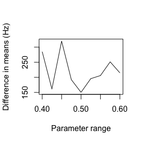

```r
plot(par.range, par.opt1$Target.match[,1], type="l", xlab="Parameter range",
    ylab="Difference in means (Hz)")
```

2. Plot proportion contained.

[figure not shown]

```r
plot(par.range, par.opt1$Prop.contained, type="l", xlab="Parameter range",
    ylab="Proportion contained")
```

3. Calculate and plot mean and quantiles of residuals of mean trait values.

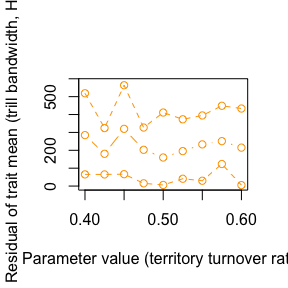

```r
res.mean.means <- apply(par.opt1$Residuals[, , 1], MARGIN=1, mean, na.rm=TRUE)
res.mean.quants <- apply (par.opt1$Residuals[, , 1], MARGIN=1, quantile,
    probs=c(0.975, 0.025), R=600, na.rm=TRUE)
plot(par.range, res.mean.means, col="orange", ylim=c(min(par.opt1$Residuals[,,1],
    na.rm=TRUE), max(par.opt1$Residuals[,,1], na.rm=TRUE)), type="b",
    xlab="Parameter value (territory turnover rate)",
    ylab="Residual of trait mean (trill bandwidth, Hz)")
points(par.range, res.mean.quants[1,], col="orange")
points(par.range, res.mean.quants[2,], col="orange")
lines(par.range, res.mean.quants[1,], col="orange", lty=2)
lines(par.range, res.mean.quants[2,], col="orange", lty=2)
```

#### Precision

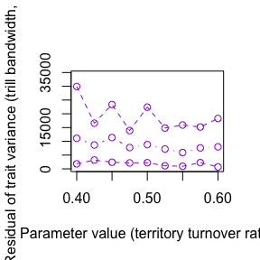

```r
#Calculate and plot mean and quantiles of residuals of variance of trait values
res.var.mean <- apply(par.opt1$Residuals[, , 2], MARGIN=1, mean, na.rm=TRUE)
res.var.quants <- apply (par.opt1$Residuals[, , 2], MARGIN=1, quantile,
    probs=c(0.975, 0.025), R=600, na.rm=TRUE)
plot(par.range, res.var.mean, col="purple",
    ylim=c(min(par.opt1$Residuals[,,2], na.rm=TRUE),
    max(par.opt1$Residuals[,,2], na.rm=TRUE)), type="b",
    xlab="Parameter value (territory turnover rate)",
    ylab="Residual of trait variance (trill bandwidth, Hz)")
points(par.range, res.var.quants[1,], col="purple")
points(par.range, res.var.quants[2,], col="purple")
lines(par.range, res.var.quants[1,], col="purple", lty=2)
lines(par.range, res.var.quants[2,], col="purple", lty=2)
```

#### Visual inspection of accuracy and precision: plot trait values for range of parameters

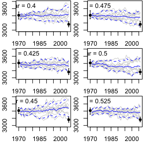

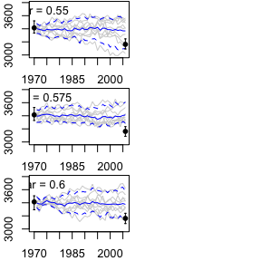

```r
par(mfcol=c(3,2),
    mar=c(2.1, 2.1, 0.1, 0.1),
    cex=0.8)
for(i in 1:length(par.range)){
plot(par.sens1$sens.results[ , , "trait.pop.mean", ], xlab="Year", ylab="Bandwidth (Hz)",
    xaxt="n", type="n", xlim=c(-0.5, years),
    ylim=c(min(par.sens1$sens.results[ , , "trait.pop.mean", ], na.rm=TRUE),
    max(par.sens1$sens.results[ , , "trait.pop.mean", ], na.rm=TRUE)))
    for(p in 1:iteration){
        lines(par.sens1$sens.results[p, , "trait.pop.mean", i], col="light gray")
        }
freq.mean <- apply(par.sens1$sens.results[, , "trait.pop.mean", i], 2, mean, na.rm=TRUE)
lines(freq.mean, col="blue")
axis(side=1, at=seq(0, 35, by=5), labels=seq(1970, 2005, by=5))

#Plot 95% quantiles
quant.means <- apply (par.sens1$sens.results[, , "trait.pop.mean", i], MARGIN=2, quantile,
    probs=c(0.95, 0.05), R=600, na.rm=TRUE)
lines(quant.means[1,], col="blue", lty=2)
lines(quant.means[2,], col="blue", lty=2)

#plot mean and CI for historic songs.
 #plot original song values
library("boot")
sample.mean <- function(d, x) {
    mean(d[x])
}
boot_hist <- boot(starting.trait, statistic=sample.mean, R=100)#, strata=mn.res$iteration)
ci.hist <- boot.ci(boot_hist, conf=0.95, type="basic")
low <- ci.hist$basic[4]
high <- ci.hist$basic[5]
points(0, mean(starting.trait), pch=20, cex=0.6, col="black")
library("Hmisc")
errbar(x=0, y=mean(starting.trait), high, low, add=TRUE)

 #plot current song values
library("boot")
sample.mean <- function(d, x) {
    mean(d[x])
}
boot_curr <- boot(target.data, statistic=sample.mean, R=100)#, strata=mn.res$iteration)
ci.curr <- boot.ci(boot_curr, conf=0.95, type="basic")
low <- ci.curr$basic[4]
high <- ci.curr$basic[5]
points(years, mean(target.data), pch=20, cex=0.6, col="black")
library("Hmisc")
errbar(x=years, y=mean(target.data), high, low, add=TRUE)

  #plot panel title
text(x=3, y=max(par.sens1$sens.results[ , , "trait.pop.mean", ], na.rm=TRUE)-100,
    labels=paste("Par = ", par.range[i], sep=""))
}
```

### Model validation with `mod.val()`

This function allows users to assess the validity of the specified model by testing model performance with a population different from the population used to build the model. The user first runs SongEvo with initial trait values from the validation population. `mod.val()` uses the summary.results array from SongEvo, along with target values from a specified timestep, to calculate the same three measures of accuracy and one measure of precision that are calculated in par.opt.

We parameterized SongEvo with initial song data from Schooner Bay, CA in 1969, and then compared simulated data to target (i.e. observed) data in 2005.

Prepare initial song data for Schooner Bay.

```r
starting.trait <- subset(song.data, Population=="Schooner" & Year==1969)$Trill.FBW
starting.trait2 <- c(starting.trait, rnorm(n.territories-length(starting.trait),
    mean=mean(starting.trait), sd=sd(starting.trait)))

init.inds <- data.frame(id = seq(1:n.territories), age = 2, trait = starting.trait2)
init.inds$x1 <-  round(runif(n.territories, min=-122.481858, max=-122.447270), digits=8)
init.inds$y1 <-  round(runif(n.territories, min=37.787768, max=37.805645), digits=8)
```

Specify and call SongEvo() with validation data

```r
iteration <- 10
years <- 36
timestep <- 1
terr.turnover <- 0.5

SongEvo2 <- SongEvo(init.inds = init.inds, females = 1.0, iteration = iteration, steps = years,
    timestep = timestep, n.territories = n.territories, terr.turnover = terr.turnover,
    integrate.dist = integrate.dist,
    learning.error.d = learning.error.d, learning.error.sd = learning.error.sd,
    mortality.a.m = mortality.a.m, mortality.a.f = mortality.a.f,
    mortality.j.m = mortality.j.m, mortality.j.f = mortality.j.f, lifespan = lifespan,
    phys.lim.min = phys.lim.min, phys.lim.max = phys.lim.max,
    male.fledge.n.mean = male.fledge.n.mean, male.fledge.n.sd = male.fledge.n.sd, male.fledge.n = male.fledge.n,
    disp.age = disp.age, disp.distance.mean = disp.distance.mean, disp.distance.sd = disp.distance.sd,
    mate.comp = mate.comp, prin = prin, all = TRUE)
```

Specify and call mod.val

```r
ts <- 36
target.data <- subset(song.data, Population=="Schooner" & Year==2005)$Trill.FBW
mod.val1 <- mod.val(summary.results=SongEvo2$summary.results, ts=ts,
    target.data=target.data)
```

Plot results from `mod.val()`

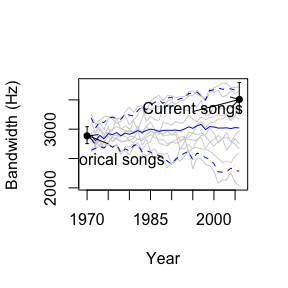

```r
plot(SongEvo2$summary.results[1, , "trait.pop.mean"], xlab="Year", ylab="Bandwidth (Hz)",
    xaxt="n", type="n", xlim=c(-0.5, 36.5),
    ylim=c(min(SongEvo2$summary.results[, , "trait.pop.mean"], na.rm=TRUE),
    max(SongEvo2$summary.results[, , "trait.pop.mean"], na.rm=TRUE)))
    for(p in 1:iteration){
        lines(SongEvo2$summary.results[p, , "trait.pop.mean"], col="light gray")
        }
freq.mean <- apply(SongEvo2$summary.results[, , "trait.pop.mean"], 2, mean, na.rm=TRUE)
lines(freq.mean, col="blue")
axis(side=1, at=seq(0, 35, by=5), labels=seq(1970, 2005, by=5))

#Plot 95% quantiles
quant.means <- apply (SongEvo2$summary.results[, , "trait.pop.mean"], MARGIN=2, quantile,
    probs=c(0.95, 0.05), R=600, na.rm=TRUE)
lines(quant.means[1,], col="blue", lty=2)
lines(quant.means[2,], col="blue", lty=2)

#plot mean and CI for historic songs.
 #plot original song values
library("boot")
sample.mean <- function(d, x) {
    mean(d[x])
}
boot_hist <- boot(starting.trait, statistic=sample.mean, R=100)
ci.hist <- boot.ci(boot_hist, conf=0.95, type="basic")
low <- ci.hist$basic[4]
high <- ci.hist$basic[5]
points(0, mean(starting.trait), pch=20, cex=0.6, col="black")
library("Hmisc")
errbar(x=0, y=mean(starting.trait), high, low, add=TRUE)

 #text and arrows
text(x=5, y=2720, labels="Historical songs", pos=1)
arrows(x0=5, y0=2750, x1=0.4, y1=mean(starting.trait), length=0.1)

 #plot current song values
library("boot")
sample.mean <- function(d, x) {
    mean(d[x])
}
boot_curr <- boot(target.data, statistic=sample.mean, R=100)
ci.curr <- boot.ci(boot_curr, conf=0.95, type="basic")
low <- ci.curr$basic[4]
high <- ci.curr$basic[5]
points(years, mean(target.data), pch=20, cex=0.6, col="black")
library("Hmisc")
errbar(x=years, y=mean(target.data), high, low, add=TRUE)

 #text and arrows
text(x=25, y=3100, labels="Current songs", pos=3)
arrows(x0=25, y0=3300, x1=36, y1=mean(target.data), length=0.1)
```

### Hypothesis testing with `h.test()`

This function allows hypothesis testing with SongEvo. To test if measured songs from two time points evolved through mechanisms described in the model (e.g. drift or selection), users initialize the model with historical data, parameterize the model based on their understanding of the mechanisms, and test if subsequently observed or predicted data match the simulated data. The output data list includes two measures of accuracy: the proportion of observed points that fall within the confidence intervals of the simulated data and the residuals between simulated and observed population trait means. Precision is measured as the residuals between simulated and observed population trait variances. We tested the hypothesis that songs of *Z. l. nuttalli* in Bear Valley, CA evolved through cultural drift from 1969 to 2005.

Prepare initial song data for Bear Valley.

```r
starting.trait <- subset(song.data, Population=="Bear Valley" & Year==1969)$Trill.FBW
starting.trait2 <- c(starting.trait, rnorm(n.territories-length(starting.trait),
    mean=mean(starting.trait), sd=sd(starting.trait)))

init.inds <- data.frame(id = seq(1:n.territories), age = 2, trait = starting.trait2)
init.inds$x1 <-  round(runif(n.territories, min=-122.481858, max=-122.447270), digits=8)
init.inds$y1 <-  round(runif(n.territories, min=37.787768, max=37.805645), digits=8)
```

Specify and call SongEvo() with test data

```r
SongEvo3 <- SongEvo(init.inds = init.inds, females = 1.0, iteration = iteration, steps = years,
    timestep = timestep, n.territories = n.territories, terr.turnover = terr.turnover,
    integrate.dist = integrate.dist,
    learning.error.d = learning.error.d, learning.error.sd = learning.error.sd,
    mortality.a.m = mortality.a.m, mortality.a.f = mortality.a.f,
    mortality.j.m = mortality.j.m, mortality.j.f = mortality.j.f, lifespan = lifespan,
    phys.lim.min = phys.lim.min, phys.lim.max = phys.lim.max,
    male.fledge.n.mean = male.fledge.n.mean, male.fledge.n.sd = male.fledge.n.sd, male.fledge.n = male.fledge.n,
    disp.age = disp.age, disp.distance.mean = disp.distance.mean, disp.distance.sd = disp.distance.sd,
    mate.comp = mate.comp, prin = prin, all = TRUE)
```

Specify and call `h.test()`

```r
target.data <- subset(song.data, Population=="Bear Valley" & Year==2005)$Trill.FBW
h.test1 <- h.test(summary.results=SongEvo3$summary.results, ts=ts,
    target.data=target.data)
```

The output data list includes two measures of accuracy: the proportion of observed points that fall within the confidence intervals of the simulated data and the residuals between simulated and observed population trait means. Precision is measured as the residuals between simulated and observed population trait variances.

```r
h.test1
```

```
#> $Residuals
#>              Residuals of mean Residuals of variance
#> Iteration 1           235.9478            17770.2656
#> Iteration 2           120.2773           110605.2032
#> Iteration 3           616.8185             9102.9054
#> Iteration 4           345.3268           116933.5083
#> Iteration 5           362.2290            25105.2834
#> Iteration 6           479.3682             1328.7926
#> Iteration 7           138.5231             5363.8848
#> Iteration 8           157.8764            12219.8601
#> Iteration 9           424.6903              718.6443
#> Iteration 10          597.7013             4495.7012
#>
#> $Prop.contained
#> [1] 0.4
```

We can plot simulated data in relation to measured data.

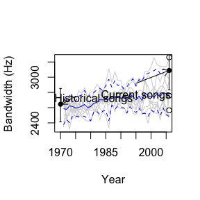

```r
#Plot
plot(SongEvo3$summary.results[1, , "trait.pop.mean"], xlab="Year", ylab="Bandwidth (Hz)",
    xaxt="n", type="n", xlim=c(-0.5, 35.5),
    ylim=c(min(SongEvo3$summary.results[, , "trait.pop.mean"], na.rm=TRUE),
    max(SongEvo3$summary.results[, , "trait.pop.mean"], na.rm=TRUE)))
    for(p in 1:iteration){
        lines(SongEvo3$summary.results[p, , "trait.pop.mean"], col="light gray")
        }
freq.mean <- apply(SongEvo3$summary.results[, , "trait.pop.mean"], 2, mean, na.rm=TRUE)
lines(freq.mean, col="blue")
axis(side=1, at=seq(0, 35, by=5), labels=seq(1970, 2005, by=5))#, tcl=-0.25, mgp=c(2,0.5,0))

#Plot 95% quantiles (which are similar to credible intervals)
quant.means <- apply (SongEvo3$summary.results[, , "trait.pop.mean"], MARGIN=2, quantile,
    probs=c(0.95, 0.05), R=600, na.rm=TRUE)
lines(quant.means[1,], col="blue", lty=2)
lines(quant.means[2,], col="blue", lty=2)

 #plot original song values
library("boot")
sample.mean <- function(d, x) {
    mean(d[x])
}
boot_hist <- boot(starting.trait, statistic=sample.mean, R=100)#, strata=mn.res$iteration)
ci.hist <- boot.ci(boot_hist, conf=0.95, type="basic")
low <- ci.hist$basic[4]
high <- ci.hist$basic[5]
points(0, mean(starting.trait), pch=20, cex=0.6, col="black")
library("Hmisc")
errbar(x=0, y=mean(starting.trait), high, low, add=TRUE)

 #plot current song values
points(rep(ts, length(target.data)), target.data)

library("boot")
sample.mean <- function(d, x) {
    mean(d[x])
}
boot_curr <- boot(target.data, statistic=sample.mean, R=100)#, strata=mn.res$iteration)
ci.curr <- boot.ci(boot_curr, conf=0.95, type="basic")
low <- ci.curr$basic[4]
high <- ci.curr$basic[5]
points(years, mean(target.data), pch=20, cex=0.6, col="black")
library("Hmisc")
errbar(x=years, y=mean(target.data), high, low, add=TRUE)

 #text and arrows
text(x=11, y=2850, labels="Historical songs", pos=1)
arrows(x0=5, y0=2750, x1=0.4, y1=mean(starting.trait), length=0.1)
text(x=25, y=2900, labels="Current songs", pos=1)
arrows(x0=25, y0=2920, x1=years, y1=mean(target.data), length=0.1)
```